# Precipitation prediction

Achir Oukelmoun

August 28, 2019

# 1 Data import and description

## 1.1 Data import and first adjustment

In this section, the training data is imported and irrelevant variables, such as hours and minutes, are removed.

Variable associated with wind directions use quantitative values from 0 - 360 but it is misleading in terms of regression since direction associated with the ends of the interval (0 and 360) are close while numerically they are not. Therefore, variable associated with wind direction are removed and 4 qualititative variables are created, each one associated with a given wind direction. An intermediate mean_direction is used. The mean_direction takes the means directions taken at different heights. The code hidden below specifies how the wind direction varibales are defined.

```r
Mean_Direction = (d[,16]+d[,14]+d[,18])/3
d$Wind_N = 0 + (Mean_Direction>=303 | Mean_Direction<56)
d$Wind_E = 0 + (Mean_Direction>=56 & Mean_Direction<123)
d$Wind_S = 0 + (Mean_Direction>=123 & Mean_Direction<236)
d$Wind_W = 0 + (Mean_Direction>=236 & Mean_Direction<303)
```

For the same reason as wind directions, the variable associated with months is transformed to factors. Indeed the variable month takes values ranging from 1 to 12, which is misleading since, for instance, the month 12 is closer to month 1 than month 10.

The names of the variables (columns) are modified so that they can be easily plotted. The actual columns names are stored in a list “t”. The key of the abreviated names is provided below:

```
## V1: Temperature.daily.mean..2.m.above.gnd.
## V2: Relative.Humidity.daily.mean..2.m.above.gnd.
## V3: Mean.Sea.Level.Pressure.daily.mean..MSL.
## V4: Total.Precipitation.daily.sum..sfc.
## V5: Snowfall.amount.raw.daily.sum..sfc.
## V6: Total.Cloud.Cover.daily.mean..sfc.
## V7: High.Cloud.Cover.daily.mean..high.cld.lay.
## V8: Medium.Cloud.Cover.daily.mean..mid.cld.lay.
## V9: Low.Cloud.Cover.daily.mean..low.cld.lay.
## V10: Sunshine.Duration.daily.sum..sfc.
## V11: Shortwave.Radiation.daily.sum..sfc.
## V12: Wind.Speed.daily.mean..10.m.above.gnd.
## V13: Wind.Speed.daily.mean..80.m.above.gnd.
## V14: Wind.Speed.daily.mean..900.mb.
## V15: Wind.Gust.daily.mean..sfc.
## V16: Temperature.daily.max..2.m.above.gnd.
## V17: Temperature.daily.min..2.m.above.gnd.
## V18: Relative.Humidity.daily.max..2.m.above.gnd.
## V19: Relative.Humidity.daily.min..2.m.above.gnd.
## V20: Mean.Sea.Level.Pressure.daily.max..MSL.
## V21: Mean.Sea.Level.Pressure.daily.min..MSL.
## V22: Total.Cloud.Cover.daily.max..sfc.
## V23: Total.Cloud.Cover.daily.min..sfc.
## V24: High.Cloud.Cover.daily.max..high.cld.lay.
## V25: High.Cloud.Cover.daily.min..high.cld.lay.
## V26: Medium.Cloud.Cover.daily.max..mid.cld.lay.
## V27: Medium.Cloud.Cover.daily.min..mid.cld.lay.
## V28: Low.Cloud.Cover.daily.max..low.cld.lay.
## V29: Low.Cloud.Cover.daily.min..low.cld.lay.
## V30: Wind.Speed.daily.max..10.m.above.gnd.
## V31: Wind.Speed.daily.min..10.m.above.gnd.
## V32: Wind.Speed.daily.max..80.m.above.gnd.
## V33: Wind.Speed.daily.min..80.m.above.gnd.
## V34: Wind.Speed.daily.max..900.mb.
## V35: Wind.Speed.daily.min..900.mb.
## V36: Wind.Gust.daily.max..sfc.
## V37: Wind.Gust.daily.min..sfc.
## V38: pluie.demain
## V39: Wind_N
## V40: Wind_E
## V41: Wind_S
## V42: Wind_W
## V43: M1
## V44: M2
## V45: M3
## V46: M4
## V47: M5
## V48: M6
## V49: M7
## V50: M8
## V51: M9
## V52: M10
## V53: M11
## V54: M12
```

## 1.2 Correlation analysis

In this section, the correlation between the variables is studied in order to avoid a high collinearity between the variables selected for the next steps of the analysis.

The correlation matrix is plotted below:

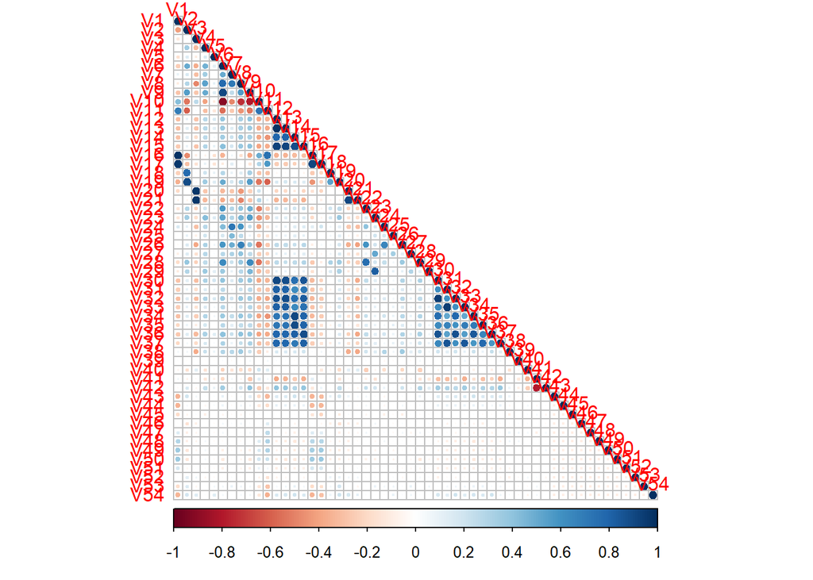

A strong correlation between several variables is observed. This is not surprising because many variables refer to the same physical quantity but taken at different heights and times.

Given that:

- There is a high colinearity between variables
- The high number of variables

A simple algorithm is developed in the following section to avoid any high collinearity between two variables.

# 2 Model Selection

## 2.1 Description of the methodology

The approach to select the best model will consist of several steps:

- Remove variables with high correlation so as to ensure that two selected variables have a correlation which is less than a given threhold S. Indeed, for each variable X, the other variables highly correlated with the variable X will be removed. This step is sensitive to the ordre of apperance of variables in the data frame, this is why varibale will be shuffled several times using pre-defined seeds. 10 shuffles will be considered and 5 correlation thresholds. Low correlation thresholds are used so as to limit the number of variable retained for the following steps of the analysis.
- Use stepAIC function to select the model with the lowest AIC
- Use several threshold probability to predict. 7 probability thresholds will be considered.

To summarize, 10 seeds for shuffling the variable, 5 threshold of correlation between variables and 7 probability thresholds will be used during a 8-fold cross-validation. Then, the set (seed, correlation threshold, and probability threshold) associated with the lowest error will be retained.

## 2.2 The R code used

The R code hidden below is the one used to automatize the choise of the model. Comments are added so as to describe better the purpose of each instruction.

```r
Seeds = 144100:144109 # Seeds for shuffling (iteration will be done with S)
Thcorr = seq(0.6,0.8,length.out=5) # Thresholds to remove highly correlated variables (iteration will be done with Tc)
Thprob = seq(0.47,0.53,length.out = 7) # Threshold for prediction (iteration will be done with Tp)
d2 = d1
n = length(d2)
ListError = NULL # Where output errors are stored
ListSeed = NULL # Where associated seed are stored
ListThc = NULL # Where associated correlation thresholds are stored
ListThp = NULL # Where associated prediction threshold are stored
ListFormula = NULL # Where associated model formula are stored

NbrFolders = 8
d0$Folders = sample(1:NbrFolders,length(d0[,1]), replace = TRUE) # Creation of 10 folders for cross-validations

for (S in Seeds){ #Iterating over seeds used to shuffle the data frame
  for (Tc in Thcorr){ #Iterating over correlation thresholds
     set.seed(seed = S)
      t1 = sample(1:n)[-cible]

      d1 = d2

      black_list = NULL
      for (i in t1){
        if (!(i %in% black_list)){
          for (j in t1){
            if(!(j %in% black_list) & j!=i){
              if (abs(mat_corr[i,j])>=Tc ) { #Variable highly correlated are black listed
                black_list = c(black_list, j)
              }
            }
          }
        }
      }
      selected_list = NULL
      selected_list_names = NULL
      for (i in 1:n){
        if (!(i%in% black_list)){ #Only columns which are not blacklisted are retained
          selected_list = c(selected_list,i)
          selected_list_names = c(selected_list_names,t_names[i])
        }
      }

      d1 = d1[selected_list] #Only selected columns are retained
      g = glm(V38~., data = d1, family = binomial)

      taic=stepAIC(g, V38~., data = d1, direction = "both", trace = 0) #Use of stepAIC to choose the best model in terms of AIC criterion

      formule = eval(taic$call[[2]]) #Recovering the fomula provided by the stepAIC function

      for (Tp in Thprob){ #Iterating over the probability threshold for prediction

        erreur_temp = NULL
        for (i in 1:NbrFolders){

          dt = d1[d0$Folders!=i,] #Data Frame for training
          dv = d1[d0$Folders == i,] #Data Frame for validation

          mt = glm(formule, family = binomial, data = dt)
          prediction = predict(mt, newdata = dv, type = 'response')
          Resultats = length(dv[,1]) - sum((prediction>Tp & dv$V38) | (prediction<Tp & !(dv$V38)))

          erreur_temp = c(erreur_temp, Resultats/length(dv[,1]))
      }

      ListError = c(ListError, mean(erreur_temp)) # Where output errors are stored
      ListSeed = c(ListSeed, S) # Where associated seed are stored
      ListThc = c(ListThc, Tc) # Where associated correlation thresholds are stored
      ListThp = c(ListThp, Tp) # Where associated prediction threshold are stored
      ListFormula = c(ListFormula, formule) # Where associated model formula are stored

    }


  }



}
```

The retained model is therefore the following:

```
## Prediction Threshold is: 0.49
```

```
## Mean error is:  0.29
```

```
## The model retained is:
```

```
##   V3 + V5 + V7 + V12 + V17 + V22 + V26 + V36 + V37 + V40 + V44 + V45 + V46 + V50 + V51 + V52 + V53
```

```
## where :
```

```
## V3: Mean.Sea.Level.Pressure.daily.mean..MSL.
## V5: Snowfall.amount.raw.daily.sum..sfc.
## V7: High.Cloud.Cover.daily.mean..high.cld.lay.
## V12: Wind.Speed.daily.mean..10.m.above.gnd.
## V17: Temperature.daily.min..2.m.above.gnd.
## V22: Total.Cloud.Cover.daily.max..sfc.
## V26: Medium.Cloud.Cover.daily.max..mid.cld.lay.
## V36: Wind.Gust.daily.max..sfc.
## V37: Wind.Gust.daily.min..sfc.
## V40: Wind_E
## V44: M2
## V45: M3
## V46: M4
## V50: M8
## V51: M9
## V52: M10
## V53: M11
```

## 2.3 Performance of the model

The perfomance of the model is estimated by a leave-one-out validation. The results are the following:

```
## The error estimate is therefore:  0.297
```

The variables used are consistant but the performance of the model seems to be relatively low. Moreover, testing several combinations through cross validation did not lead to a significant enhancement of the model performance.

## 2.4 Model Interpretation

The summary of the model selected is as follows:

```
##
## Call:
## glm(formula = formule[[1]], family = binomial, data = d2)
##
## Deviance Residuals:
##     Min       1Q   Median       3Q      Max
## -2.4628  -0.8849  -0.2698   0.9185   2.1400
##
## Coefficients:
##              Estimate Std. Error z value Pr(>|z|)
## (Intercept) 96.305858  11.279425   8.538  < 2e-16 ***
## V3          -0.094581   0.010957  -8.632  < 2e-16 ***
## V5           0.388962   0.291979   1.332 0.182809
## V7           0.012451   0.003852   3.233 0.001227 **
## V12         -0.065382   0.026315  -2.485 0.012970 *
## V17         -0.027883   0.013996  -1.992 0.046344 *
## V22         -0.006129   0.003223  -1.902 0.057192 .
## V26          0.011744   0.002433   4.828 1.38e-06 ***
## V36          0.021229   0.008094   2.623 0.008718 **
## V37          0.025801   0.015923   1.620 0.105156
## V40         -0.791773   0.250867  -3.156 0.001599 **
## V44TRUE     -1.033981   0.284193  -3.638 0.000274 ***
## V45TRUE     -1.117963   0.285764  -3.912 9.15e-05 ***
## V46TRUE     -0.885264   0.261522  -3.385 0.000712 ***
## V50TRUE     -0.397736   0.243846  -1.631 0.102870
## V51TRUE     -0.765203   0.256449  -2.984 0.002847 **
## V52TRUE     -0.902197   0.243622  -3.703 0.000213 ***
## V53TRUE     -1.037328   0.279026  -3.718 0.000201 ***
## ---
## Signif. codes:  0 '***' 0.001 '**' 0.01 '*' 0.05 '.' 0.1 ' ' 1
##
## (Dispersion parameter for binomial family taken to be 1)
##
##     Null deviance: 1724.5  on 1243  degrees of freedom
## Residual deviance: 1378.5  on 1226  degrees of freedom
## AIC: 1414.5
##
## Number of Fisher Scoring iterations: 5
```

# 3 Testing the model

## 3.1 Importing the test data set

In this section, the test data set is imported and the same transformation on the variable are applied so as to make the predictions. The predictions are stored in the variable “Pluie.demain”.

So to check preliminarly that the prediction are consistent with previous training data, the following mosaic plot provides the beakdown of the prediction by month.

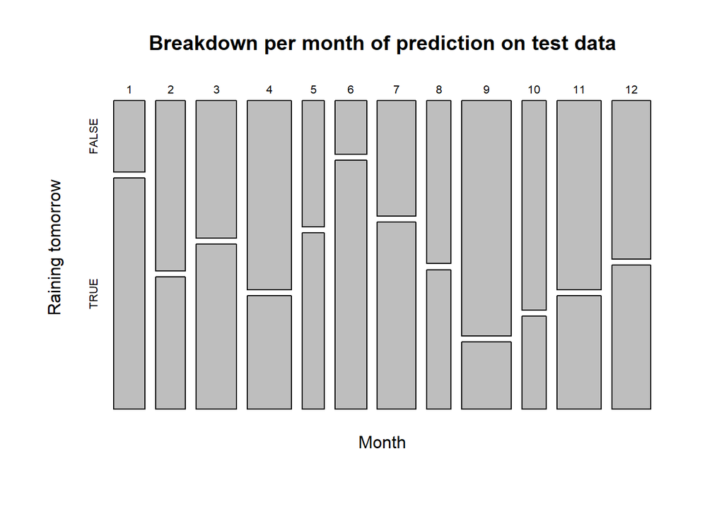

While the breakdown of the prediction by month of training data is provided below:

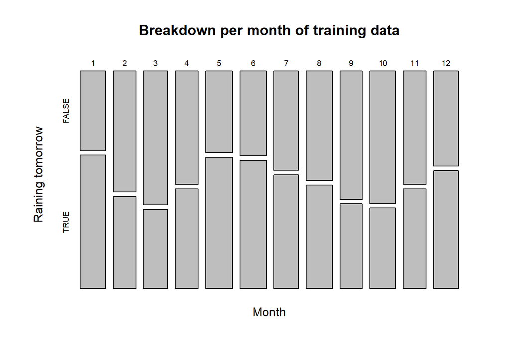

By comparing the plots above, roughly the same behavior is observed but not exactly the same since here June in the predicted to the rainiest month while in the training data June is the third rainiest month. Finally, the model that we have does not have a high accuracy level but provides acceptable results.